# Combining plots in a grid

Author

Charlotte Soneson, Michael Stadler

## Summary

This document illustrates how to use `cowplot` and `patchwork` (two companion packages to `ggplot2`) to:

- combine multiple panels into a single figure
- include a non-ggplot2 panel and set a joint title for the figure

## Prepare data

Run the following code to prepare the data used in this document:

```r
suppressPackageStartupMessages({
    library(tibble)
    library(swissknife)
    library(ggplot2)
    library(cowplot)
    library(patchwork)
})

loadExampleData("mycars")
```

```
`mycars`: re-encoded version of `datasets::mtcars`
```

```r
tibble(mycars)
```

```
# A tibble: 32 × 13
     mpg cyl    disp    hp  drat    wt  qsec    vs    am  gear  carb
   <dbl> <fct> <dbl> <dbl> <dbl> <dbl> <dbl> <dbl> <dbl> <dbl> <dbl>
 1  21   6      160    110  3.9   2.62  16.5     0     1     4     4
 2  21   6      160    110  3.9   2.88  17.0     0     1     4     4
 3  22.8 4      108     93  3.85  2.32  18.6     1     1     4     1
 4  21.4 6      258    110  3.08  3.22  19.4     1     0     3     1
 5  18.7 8      360    175  3.15  3.44  17.0     0     0     3     2
 6  18.1 6      225    105  2.76  3.46  20.2     1     0     3     1
 7  14.3 8      360    245  3.21  3.57  15.8     0     0     3     4
 8  24.4 4      147.    62  3.69  3.19  20       1     0     4     2
 9  22.8 4      141.    95  3.92  3.15  22.9     1     0     4     2
10  19.2 6      168.   123  3.92  3.44  18.3     1     0     4     4
# ℹ 22 more rows
# ℹ 2 more variables: engine_shape <fct>, transmission <fct>
```

## Create individual panels

We first create the individual plots that we will later use as panels in the combined plot.

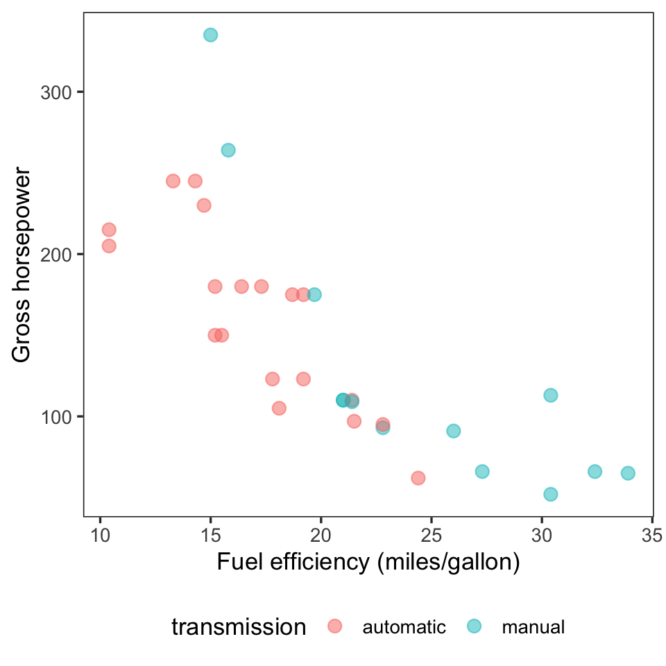

```r
p1 <- ggplot(data = mycars, mapping = aes(x = mpg, y = hp)) +
    geom_point(size = 3, alpha = 0.5, aes(color = transmission)) +
    labs(x = "Fuel efficiency (miles/gallon)", y = "Gross horsepower") +
    theme_bw(13) +
    theme(panel.grid = element_blank(),
          legend.position = "bottom")
p1
```

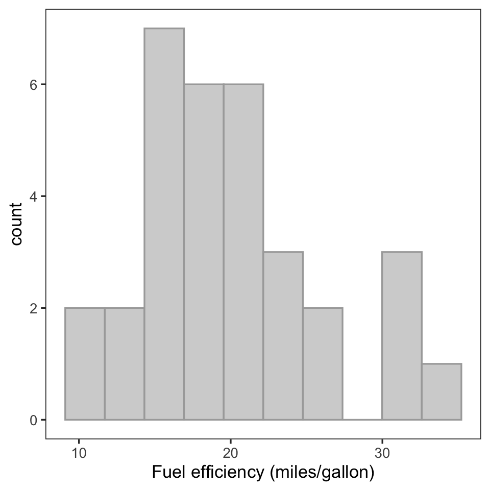

```r
p2 <- ggplot(data = mycars, mapping = aes(x = mpg)) +
    geom_histogram(bins = 10,
                   color = "darkgrey", fill = "lightgrey") +
    labs(x = "Fuel efficiency (miles/gallon)") +
    theme_bw(13) +
    theme(panel.grid = element_blank(),
          legend.position = "bottom")
p2
```

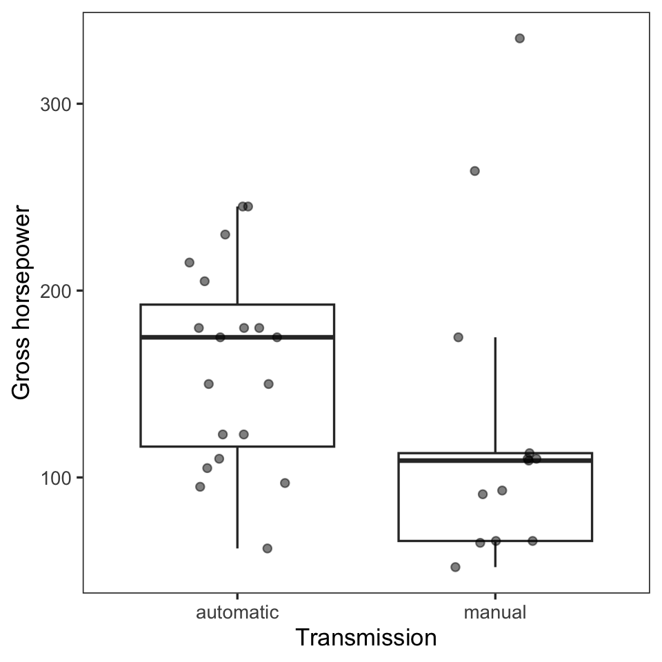

```r
p3 <- ggplot(data = mycars, mapping = aes(x = transmission, y = hp)) +
    geom_boxplot(outlier.size = -1) +
    geom_jitter(width = 0.2, height = 0, alpha = 0.5) +
    labs(x = "Transmission", y = "Gross horsepower") +
    theme_bw(13) +
    theme(panel.grid = element_blank(),
          legend.position = "bottom")
p3
```

## Combine panels into final figure (cowplot)

```r
## Generate image object from jpg file
img <- ggdraw() +
    draw_image("https://publicdomainvectors.org/photos/johnny_automatic_puppy.png")
```

Next, we combine the three plots and the puppy image into a single figure, using a grid layout.

[figure not shown]

```r
comb <- plot_grid(
    p3, p1, img, p2,
    ncol = 2, labels = c("A", "B", "", "C"),
    align = "hv", axis = "tblr", rel_widths = c(0.5, 1)
)
comb
```

We can also set a joint title for the full plot (this has to be generated separately and added as an additional figure component).

[figure not shown]

```r
## Create a joint title
jointtitle <- ggdraw() +
    draw_label("Combined plot title",
               fontface = "bold", x = 0, hjust = 0)

plot_grid(jointtitle,
          comb,
          ncol = 1, rel_heights = c(0.1, 1)
)
```

## Combine panels into final figure (patchwork)

Here we create the same combined figure as above, but now using `patchwork::wrap_plots` rather than `cowplot`.

[figure not shown]

```r
wrap_plots(p3, p1, img, p2, ncol = 2) +
    plot_layout(widths = c(0.5, 1)) +
    plot_annotation(tag_levels = list(c("A", "B", "", "C")),
                    title = "Combined plot title",
                    theme = theme(plot.title = element_text(face = "bold")))
```

Here’s another visualization, where the different rows distribute the plot widths in different ways.

[figure not shown]

```r
(p3 + p1 + plot_layout(widths = c(1, 1))) / (img + p2 + plot_layout(widths = c(0.5, 1))) +
    plot_annotation(tag_levels = list(c("A", "B", "", "C")),
                    title = "Combined plot title",
                    theme = theme(plot.title = element_text(face = "bold")))
```

## Remarks

- If panels have a shared legend and we only wish to include it once, we can extract it using `cowplot::get_legend()` and include it as a separate panel (note that some [issues](https://github.com/wilkelab/cowplot/issues/202) were reported with this functionality starting with `ggplot2` 3.5.0).
- To include `ggpairs` panels, see the tips [here](https://fmicompbio.github.io/intermediate_ggplot2_FMI2023/intermediate_ggplot2.html#combining-plot-panels).